# Party/Date hub project

Flavio Passante

22/07/2022

# Escherichia Coli Network Analysis

## Introduction

Proteins interactions can be described with interaction networks called PPI **(Protein-Protein Interaction)** and are commonly represented as undirected graphs (whose edges connecting different interacting proteins have no direction). However, PPI are not static systems, indeed they have both space and time dimensions. Microarray expression profiles provide valuable temporal information on protein-protein interactions and network models allow to incorporate the different time dimension. The link between microarray expression profiles and network lays down on the assumption that product of co-regulated genes have higher chances of interacting with each other. The temporal characteristics of hub proteins (protein with high degree, i.e., proteins connected to many other proteins) is determined by computing the correlation of their mRNA expression with the expressions for their partner proteins. This computation allowed to determine two main types of hub:

- **Party hub(intra-module hubs)**: hub proteins with relatively high correlations between their mRNA levels and the one of partners. Party hub proteins are assumed to be interacting with their partners concurrently. They have local role in a network, with strong connections within functional modules
- **Date hub(inter-module hubs)**: hubs with low correlation in the expression levels with their partners, interactin with them at different times. Date hubs interconnect functional modules giving rise to the network topology and consequently have a global role.

This project is focused on the connection between the concepts of party/date hub and the one of **betweennes centrality**. Betweennes is the typical global centrality measure and commonly used when trying to find bridges that interconnect different functional modules, as what date hubs are supposed to do. It is defined as the number of times a node is part of the shortest path between two other nodes. When a node has high importance within the graph, a large number of the shortest paths pass trough the node in the graph itself.

## Loading Data

### Protein-Protein interaction Network

Starting point is E.Coli (strain Eck12) Protein-Protein Interaction (PPI) network.

```
##   protein1 protein2 homology experiments experiments_transferred database
## 1    b0002    b0003        0           0                     122        0
## 2    b0002    b0004        0           0                     122        0
## 3    b0002    b0008        0           0                       0        0
## 4    b0002    b0014        0           0                      92        0
## 5    b0002    b0026        0           0                       0        0
## 6    b0002    b0031        0           0                       0        0
##   database_transferred textmining textmining_transferred combined_score
## 1                    0          0                    477            521
## 2                    0          0                    539            577
## 3                    0          0                    128            128
## 4                    0          0                    152            197
## 5                    0          0                    209            209
## 6                    0          0                    540            540
```

It’s in dataset form and it’s formed by different variables but we will consider only few of them for this project:

- **Protein1/2**: two columns representing protein 1 interacting with protein 2;
- **Experiments**: indicator for the confidence, goodness of the reported interaction. The higher, the more valuable the interaction;
- **Experiments Transferred**: similar to experiments, but takes into accounts also other species. It’s a further quality parameter to assess if the corresponding interaction is appreciated also in other species;

Only **Experiments** will be considered in this analysis.

### Compendium (Expression Data)

In order to link concepts of date/party hub with the one of bottleneck, gene expression compendium is required. It’s substantially a gene expression data containing expression values for each protein in several conditions. The compendium is formed by three components:

- **A**: dataset with:
  - *rows* representing ReqSeq accession numbers of each protein;
  - *columns*:
    - Gene Symbol (protein name);
    - Protein ID;

  ```
  ##                                   GeneSymbol Protein ID
  ## lcl|NC_000913.3_cds_NP_414542.1_1       thrL      b0001
  ## lcl|NC_000913.3_cds_NP_414543.1_2       thrA      b0002
  ## lcl|NC_000913.3_cds_NP_414544.1_3       thrB      b0003
  ## lcl|NC_000913.3_cds_NP_414545.1_4       thrC      b0004
  ## lcl|NC_000913.3_cds_NP_414546.1_5       yaaX      b0005
  ## lcl|NC_000913.3_cds_NP_414547.1_6       yaaA      b0006
  ```

- **ALL_FINAL_Nreads**: Number of reads for each protein in each condition;

  ```
  ##       DRR091867 DRR091875 DRR091882 DRR100424 DRR100428 ERR1025366 ERR1370908
  ## b0001         6         2         0         8        12       1122          0
  ## b0002        73       107       365       703       269        747        160
  ## b0003        19        30        74       343       286        516        134
  ## b0004        20        36        72       535       423        418        119
  ## b0005         1         1         3        61        40         51        132
  ## b0006         6        21        23       303       313         61         54
  ##       ERR1370919 ERR1399586 ERR1399594
  ## b0001          0        127        239
  ## b0002        130       2457        959
  ## b0003        107        887        354
  ## b0004        100       1731        558
  ## b0005         27         36        132
  ## b0006         84         93        109
  ```

- **ALL_FINAL_TPM**: Transcript Per Million. The actual expression value for each protein in each condition. Rows contain proteins and columns contain conditions. This dataset is processed in two ways:
  - Transposition to allow further downsteam analyses.
  - Duplicate Removal: duplicates are removed in order to avoid ambiguity when assigning a neighbor to a protein node.

```
##                b0001      b0002     b0003      b0004     b0005      b0006
## DRR091867  313.40200  23.144200  17.49257  12.790550  4.352604   6.851082
## DRR091875   59.32732  16.597211  13.71930  11.350018  2.330382  11.982375
## DRR091882    0.00000  46.247058  27.22265  18.390723  5.235261  10.498114
## DRR100424  245.64457 325.598332 210.12565 300.017224 88.168046 184.618220
## DRR100428  465.32113 148.943297 165.69833 218.828457 48.746921 169.598287
## ERR1025366 609.47488   3.063589   5.87840   3.374628  2.191994   0.848382
##                 b0007      b0008      b0009      b0010
## DRR091867    0.568696  320.32924  32.224722  16.883883
## DRR091875    5.038024  104.67323  59.513795  30.816288
## DRR091882    9.086690  106.11904  77.328234 112.774161
## DRR100424   93.077215 5081.85182 171.278189  78.325050
## DRR100428  136.154276 7324.44606 216.629682  78.770463
## ERR1025366   2.814762   37.53472   3.833255   8.286483
```

To retain “good qualities” interaction, we need to look at the distribution of the “experiments” value. Interactions with a confidence equal to 0 can be excluded since represents interactions not experimentally validated.

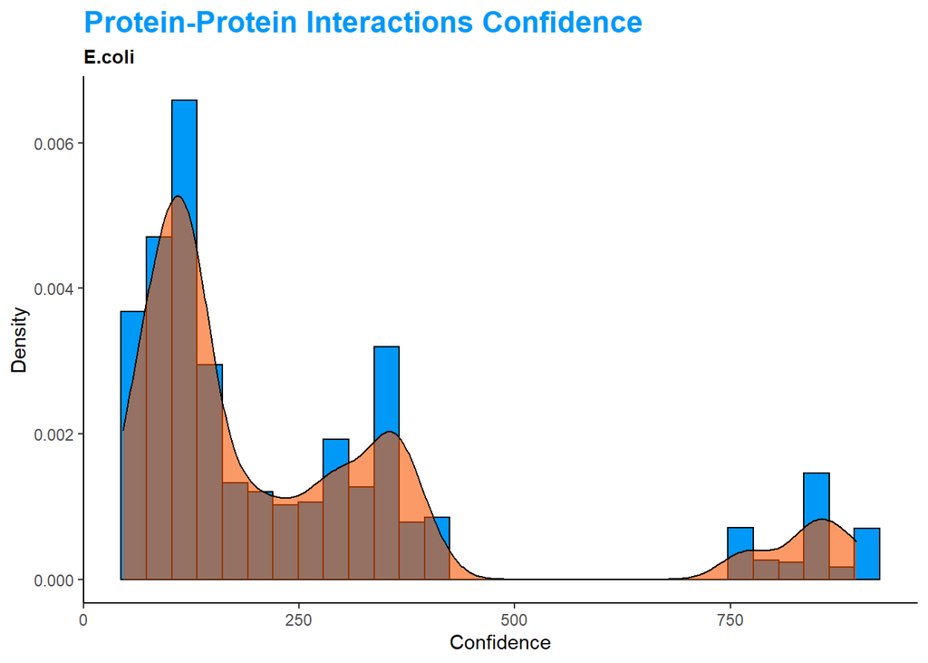

The confidence of interactions follows a sort of bimodal distribution when its value is below 500 and shows a peak of good confidence interactions around 800. Different analyses will be initialized varying the treshold filtering upon confidence. In particular, 3 tresholds will be set leading to 3 different analyses:

1. High-Confidence interactions: `minExp > 600`
2. Mid-Confidence Interaction `minExp > 250`
3. Low-Confidence Interaction `minExp > 0`

The different results obtained by the analyses will be compared to establish whether the loss of information given by the exclusion of low-confidence interaction does not affect the quality of the results.

## High-Confidence Protein-Protein Interactions Analysis

```r
#change min_exp and plot
minExp <- 600
ECOEXP_hq <-as.data.frame(cbind(Ecoli_PPI$protein1[Ecoli_PPI$experiments>minExp],
                            Ecoli_PPI$protein2[Ecoli_PPI$experiments>minExp],
                            Ecoli_PPI$experiments[Ecoli_PPI$experiments>minExp]))
colnames(ECOEXP_hq)<-c("Protein1","Protein2","Confidence")
ECOEXP_hq$Confidence<-as.numeric(ECOEXP_hq$Confidence)
```

The network can now be created and simplified by removal of both multiple edges and self loops.

```
## IGRAPH dd6b2ba DN-- 342 628 --
## + attr: name (v/c)
## + edges from dd6b2ba (vertex names):
##  [1] b0009->b1224 b0009->b3856 b0014->b0015 b0014->b0894 b0014->b1000
##  [6] b0014->b1084 b0014->b2231 b0014->b2614 b0014->b3164 b0014->b3461
## [11] b0014->b4143 b0015->b0014 b0023->b0693 b0023->b2938 b0032->b0033
## [16] b0033->b0032 b0054->b0641 b0083->b0093 b0084->b0093 b0084->b0149
## [21] b0089->b0093 b0093->b0083 b0093->b0084 b0093->b0089 b0093->b0890
## [26] b0093->b3933 b0094->b0095 b0094->b3251 b0095->b0094 b0095->b1176
## [31] b0095->b2412 b0095->b3251 b0098->b0736 b0098->b1094 b0098->b3609
## [36] b0143->b3164 b0143->b4172 b0149->b0084 b0149->b3933 b0149->b4058
## + ... omitted several edges
```

### Node categories

Nodes are splitted into 4 categories:

1. Bottleneck hubs (BH): hubs with high degree and betweenness
2. Non-Bottleneck Hubs (NBH): hubs with high degree but low betwenness
3. Bottleneck non-Hubs (BNH): node with high betweenness but low degree
4. Non-Bottleneck non-Hubs (NBNH): node with low betweenness and degree.

In order to properly distinguish high betweenness/degree from low values, a treshold for quantiles can be set. In this case a soft one is used (0.9) for both parameters. This allows to group the nodes with the best values for these parameters into the top 10% given by the quantile.

```r
###define centrality measures for betweenness and degree

eco_ppi_hq_betwennes <-betweenness(eco_ppi_graph_hq,directed=FALSE)

eco_ppi_hq_degree<- degree(eco_ppi_graph_hq)

### defining threshold
treshold <- 0.9

betwenness_treshold <-quantile(eco_ppi_hq_betwennes,treshold)

degree_treshold <-quantile(eco_ppi_hq_degree,treshold)

#categorize nodes

BH<-V(eco_ppi_graph_hq)$name[eco_ppi_hq_betwennes>=betwenness_treshold & eco_ppi_hq_degree>=degree_treshold]

#non-bottleneck hubs (NBH)
NBH<-V(eco_ppi_graph_hq)$name[eco_ppi_hq_betwennes<betwenness_treshold & eco_ppi_hq_degree>=degree_treshold]

#bottleneck non-hub (BNH)
BNH<-V(eco_ppi_graph_hq)$name[eco_ppi_hq_betwennes>=betwenness_treshold & eco_ppi_hq_degree<degree_treshold]

#non bottleneck non hubs NBNH
NBNH<-V(eco_ppi_graph_hq)$name[eco_ppi_hq_betwennes<betwenness_treshold & eco_ppi_hq_degree<degree_treshold]
```

The distribution of each centrality measure can be visualized.

```r
nodes_names <- c(BH, NBH, BNH, NBNH)
stats_hq <- data.frame(row.names = nodes_names,
                    list(type = c(rep('BH', length(BH)),
                                  rep('NBH', length(NBH)),
                                  rep('BNH', length(BNH)),
                                  rep('NBNH', length(NBNH))),
                    betwenness = eco_ppi_hq_betwennes[nodes_names],
                    degree = eco_ppi_hq_degree[nodes_names]))

centralities <- cbind(stats_hq$degree, stats_hq$betwenness)
```

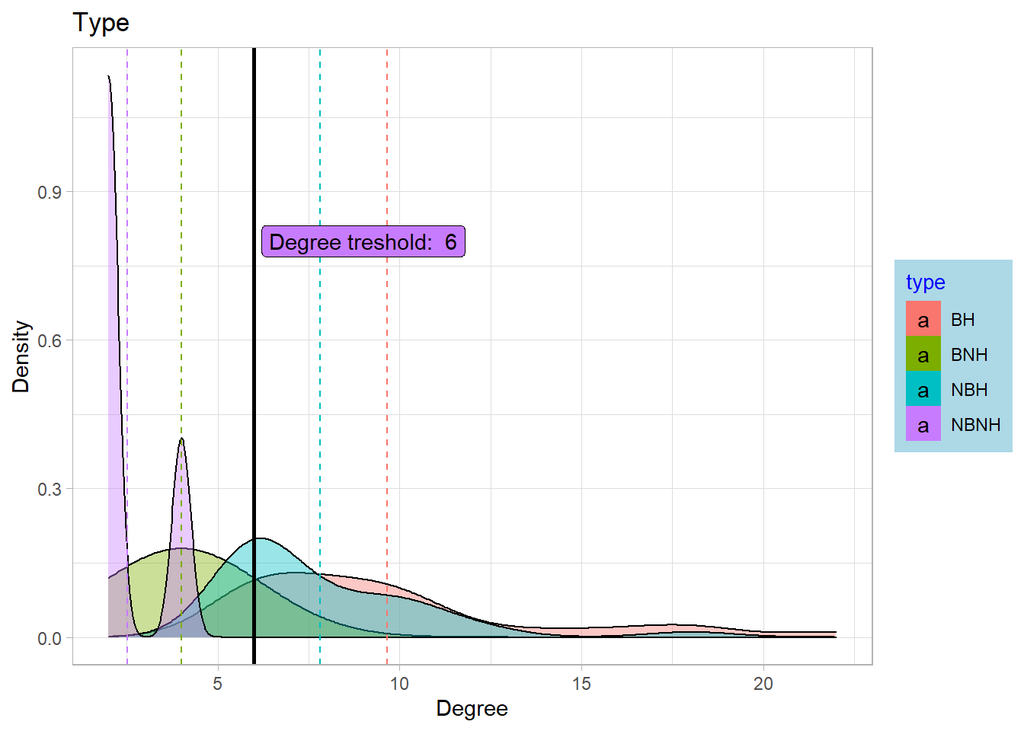

```r
#calculate the mean for each group and for each stat
mean_deg <- ddply(stats_hq, 'type', summarise, grp.mean_deg = mean(degree))
mean_bet <- ddply(stats_hq, 'type', summarise, grp.mean_bet = mean(betwenness))

degree_distr <- ggplot(stats_hq, aes(x=degree, fill=type)) +
  geom_density(alpha = 0.4)+
  geom_vline(data=mean_deg, aes(xintercept=grp.mean_deg, color=type),
             linetype="dashed") +
  geom_vline(xintercept = degree_treshold, size = 1 ) +
  geom_label(aes(x=degree_treshold +3, y = 0.8, label = paste('Degree treshold: ', degree_treshold))) +
  xlab('Degree') +
  ylab('Density') + labs(title = 'Type') +
  theme_light() +
  theme(legend.title = element_text(color = 'blue', size  = 10), legend.background = element_rect((fill = 'lightblue'), color = NA), )


betwennes_distr <- ggplot(stats_hq, aes(x=betwenness, color=type)) +
  geom_freqpoly() +
  geom_vline(xintercept = betwenness_treshold, size = 1) +
  geom_label(aes(x=betwenness_treshold + 800, y=350, label=paste('Betweennes treshold: ', betwenness_treshold))) +
  xlab('Betwenennes') +
  ylab('Density') +
  theme_light() +
  theme(legend.title = element_text(color = 'blue', size  = 10), legend.background = element_rect((fill = 'lightblue'), color = NA), )


degree_distr
```

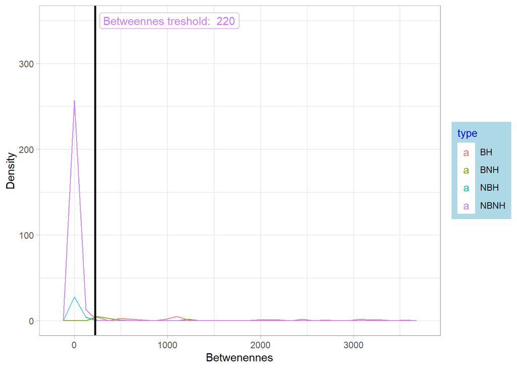

```r
betwennes_distr
```

As expected, hubs (bottleneck and non bottleneck) have higher mean degrees level with respect to non-hubs. From betwenness density plot, it’s possible to appreciate that the treshold splits groups according to the “bottleneck” property, independently from being or not an hub. This feature can be furher investigated by means of a violin plot.

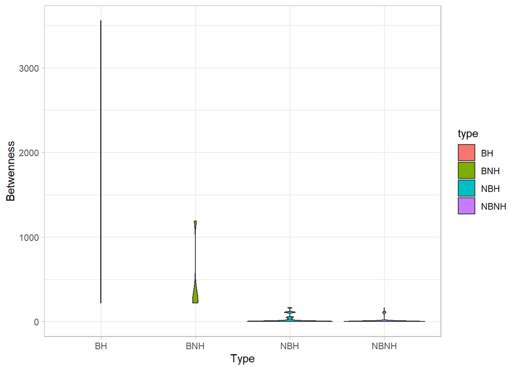

```r
betweenness_violin <- ggplot(stats_hq, aes(x=type, y = betwenness, fill = type)) +
                            geom_violin(outlier.shape = NA) +
  ylab('Betwenness') +
  xlab('Type') +
  theme_light()
betweenness_violin
```

The shape of distributions are not clear especially for bottleneck category, in which, ideally, the shape should be more similar. This is because the treshold chosen has discarded most of interactions. Indeed:

```
##   BH  BNH  NBH NBNH
##   29   11   32  270
```

Anyway, bottleneck nodes have overall higher values for betwenness. For what regard non-bottleneck category, we can see overall lower values for bottleneck and plenty nodes (hubs and non-hubs) with a 0-value of betweenness.

### Compute neighborhood for each type

Neighborhood for each node type is computed by considering only the neighbors and not the hub itself. This is because the aim of this project is to proper classify date and party hubs considering correlation in expression values. Party hubs should contain several consitutive genes (hub) in which there are not big fluctuations in gene co-expression with their neighbors among different conditions. This means that the computation of correlation in gene expression for these nodes is useless in this persective. For this reason, this step is carried out calculating correlations between interactors of the hub and not between hubs and their interactors.

```r
#computing neighbors and retrieving neighbor genes for BH
BH_neighbors <- neighborhood(eco_ppi_graph_hq,1, BH)
NBH_neighbors <- neighborhood(eco_ppi_graph_hq, 1, NBH)
BNH_neighbors <- neighborhood(eco_ppi_graph_hq, 1, BNH)
NBNH_neighbors <- neighborhood(eco_ppi_graph_hq, 1, NBNH)

#remove hubs from BH neighbors
for (i in 1:length(BH_neighbors)) {
  BH_neighbors[[i]] <- BH_neighbors[[i]][BH_neighbors[[i]]$name != BH[i]]
}

#remove hubs from NBH neighbors
for (i in 1:length(NBH_neighbors)) {
  NBH_neighbors[[i]] <- NBH_neighbors[[i]][NBH_neighbors[[i]]$name != NBH[i]]
}

#remove hubs from BNH neighbors
for (i in 1:length(BNH_neighbors)) {
  BNH_neighbors[[i]] <- BNH_neighbors[[i]][BNH_neighbors[[i]]$name != BNH[i]]
}

#remove hubs from NBNH neighbors
for (i in 1:length(NBNH_neighbors)) {
  NBNH_neighbors[[i]] <- NBNH_neighbors[[i]][NBNH_neighbors[[i]]$name != NBNH[i]]
}
```

Having computed the neighborhood for each type, now it’s time for correlation values. Both pearson and spearman correlation can be used for this purpose, but the latter should suits best since it doesn’t assume a linear correlation between two variables, in this case between two gene expression values.

The distribution of correlation for each type can also be evaluated with a plot showing a value representing the amount of interaction that falls within a particular bin, for each bin.

#### Correlation in gene expression for BH

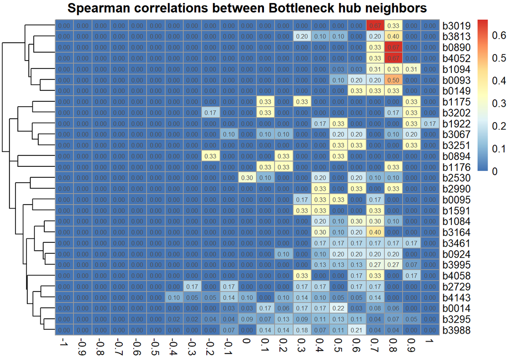

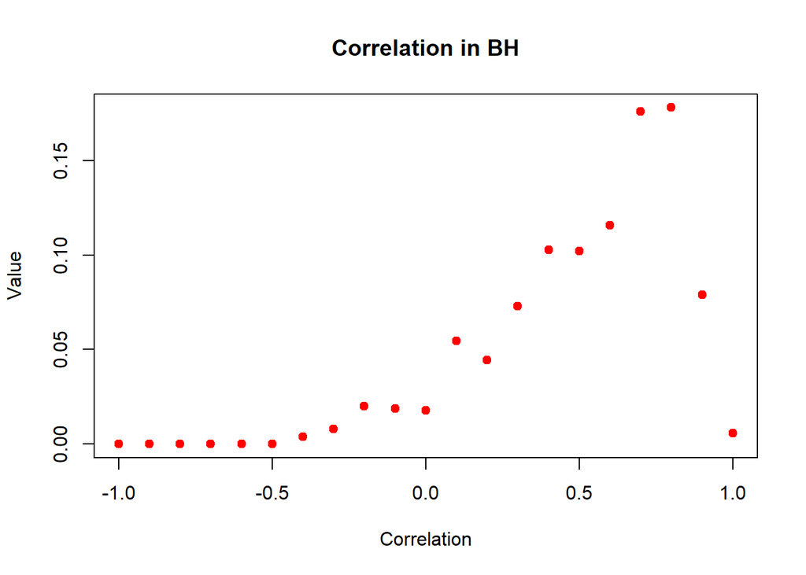

#### Correlation in gene expression for NBH

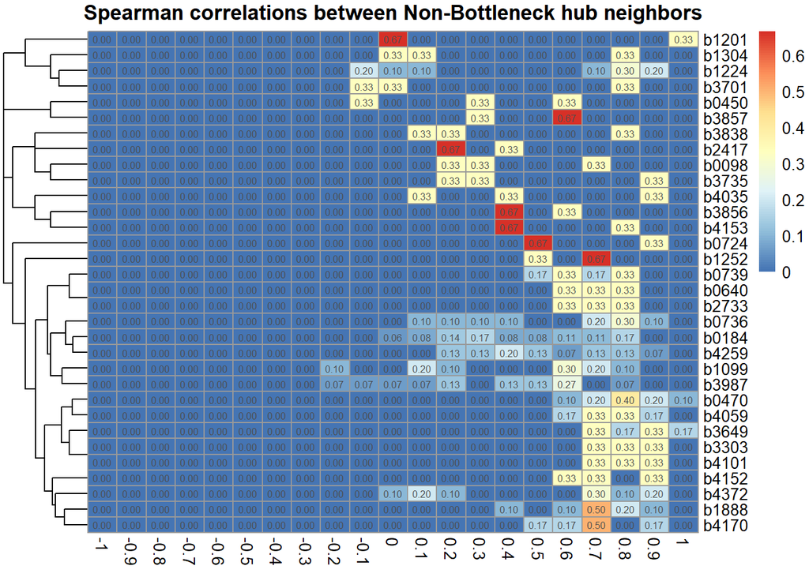

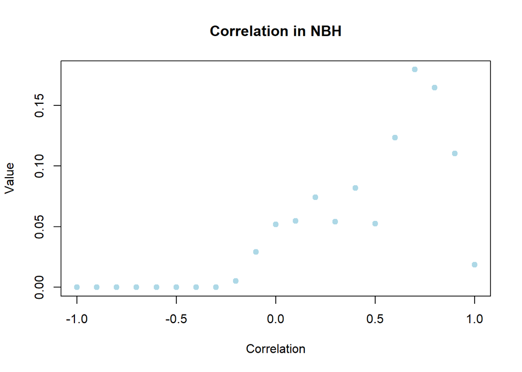

By comparing BH with NBH by looking at pattern in correlations, the former appears to show two areas that divide a more spread distribution (in the lower part) from a slighty more compact one in the upper part. The dendrogram depicting hierchical clustering plotted on the left does not provide a strong result for both BH and NBH.

The distribution of correlation values for each bin in NBH is not so different with respect to BH for higher values of correlation.

#### Correlation in gene expression for BNH and NBNH

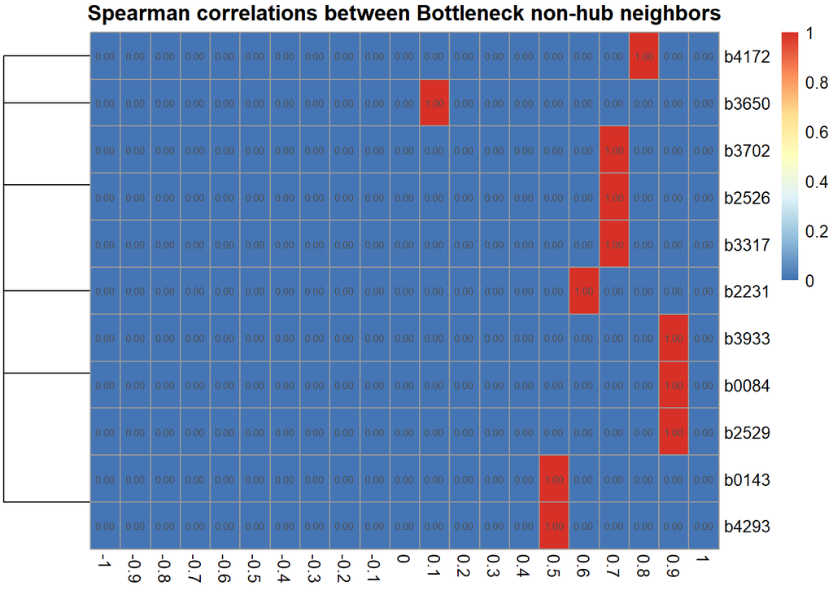

#### Correlation in gene expression for NBNH

```r
#NBNH contains neighborhood with only one interactor. These can be removed
mask <- array()
for (i in 1:length(NBNH_neighbors)) {
  mask[i] <- length(NBNH_neighbors[[i]]) != 1
}
NBNH_neighbors <- NBNH_neighbors[mask]
```

[figure not shown]

BNH and NBNH, beeing non-hubs, does not show any sign of party/date-like pattern as expected. They can be excluded for the rest of the analyses.